# FordGoBike Dataset analysis

## 3- Do subscribers enable BikeShare more than customers?

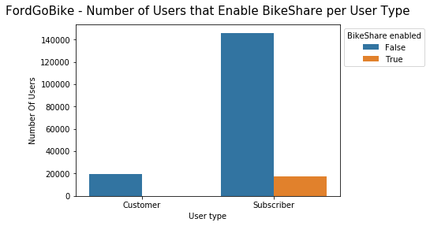

```python
sns.countplot(data=df, x = 'user_type', hue='bike_share_for_all_trip');
plt.legend(bbox_to_anchor=(1, 1),title = 'BikeShare enabled');
plt.xlabel('User type');
plt.ylabel('Number Of Users');
plt.title('FordGoBike - Number of Users that Enable BikeShare per User Type',fontsize=15, y=1.03);
```

```python
counts = df.groupby(['member_gender','bike_share_for_all_trip']).size()
counts = counts.reset_index(name='count')
counts = counts.pivot(index='member_gender', columns='bike_share_for_all_trip', values='count')
```

```python
counts
```

| bike_share_for_all_trip member_gender | False | True |
| --- | --- | --- |
| Female | 37230 | 3600 |
| Male | 117507 | 13084 |
| Other | 3003 | 648 |

## 4- Which gender enables BikeShare more.

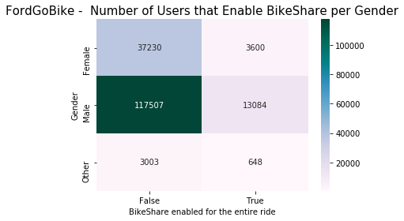

```python
sns.heatmap(counts,annot=True,fmt='d', cmap='PuBuGn');
plt.xlabel('BikeShare enabled for the entire ride');
plt.ylabel('Gender');
plt.title('FordGoBike -  Number of Users that Enable BikeShare per Gender',fontsize=15);
```

From the viusalization we can tell the following:

- The highiest number of BikeShare enabled gender is Male, but the highiest percentage is Other

# Multivariate Exploration.

## 1- Are subscribers more active during the week than customers?

```python
df['duration_sec'].describe()
```

```
count    183337.000000
mean        726.109656
std        1794.731673
min          61.000000
25%         325.000000
50%         514.000000
75%         796.000000
max       85444.000000
Name: duration_sec, dtype: float64
```

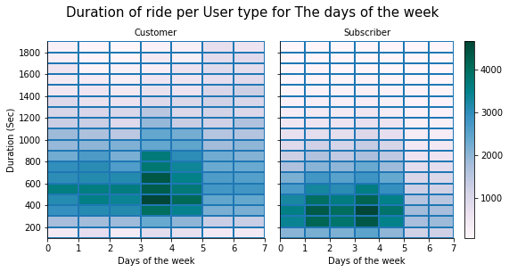

```python
x_bins = np.arange(0,8,1)
y_bins = np.arange(100,2000, 100)
g = sns.FacetGrid(data=df, col='user_type', height=4);
g.map(plt.hist2d, 'day_name', 'duration_sec', cmap = 'PuBuGn', bins=[x_bins,y_bins]);
plt.colorbar();
g.set_axis_labels("Days of the week", "Duration (Sec)");
g.set_titles(col_template="{col_name}");
g.fig.suptitle('Duration of ride per User type for The days of the week',y='1.05',fontsize=15);
```

From the previous visualization, we find the following insights:

- Customers are more active during weekends than subscribers.
- Subscribers are more active during weekdays than customers.
- On average, customers go for longer rides than subscribers.

## 2-Whats the duration for each gender/User type

```python
df.groupby(['user_type','member_gender'])['duration_sec'].mean()
```

```
user_type   member_gender
Customer    Female           1422.947051
            Male             1253.643384
            Other            1589.125275
Subscriber  Female            696.484247
            Male              616.401618
            Other             912.232478
Name: duration_sec, dtype: float64
```

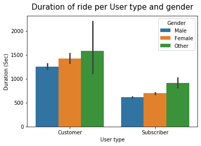

```python
ax = sns.barplot(data=df, x = 'user_type', y='duration_sec', hue='member_gender',hue_order=['Male','Female','Other'])
ax.legend(title='Gender');
plt.xlabel('User type');
plt.ylabel('Duration (Sec)');
plt.title('Duration of ride per User type and gender',fontsize=15,y=1.03);
```

From the previous visualization, we find the following insights:

- in general, customers have longer rides across all genders than subscribers.
- 'Other' genders have the longist rides followed by female then male.
- 'Other' genders have the highiest variance and outliers in terms of duration

## 3- Whats the duration of BikeShare users per gender.

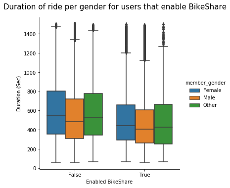

```python
majority = df.loc[df.duration_sec < 1500]
g = sns.catplot(data=majority, x='bike_share_for_all_trip', y='duration_sec',hue='member_gender',kind='box')

g.set_axis_labels("Enabled BikeShare", "Duration (Sec)");
g.set_titles(col_template="{col_name}");
g.fig.suptitle('Duration of ride per gender for users that enable BikeShare',y='1.05',fontsize=15);
```

From the previous visualization, we find the following insights:

- Users that enable BikeShare on average take shorter trips than users that dont enable it